# Lab8

Anna Matarazzo

4/15/2021

### Problems

Consider a 2x2 design. Assume the DV is measured from a normal distribution with mean 0, and standard deviation 1. Assume that the main effect of A causes a total shift of .5 standard deviations of the mean between the levels. Assume that level 1 of B is a control, where you expect to measure the standard effect of A. Assume that level 2 of B is an experimental factor intended to reduce the effect of A by .25 standard deviations.

A. create a ggplot2 figure that depicts the expected results from this design (2 points)

Conduct simulation-based power analyses to answer the questions.

B. How many subjects are needed to detect the main effect of A with power = .8? (2 points)

C. How many subjects are needed to detect the interaction effect with power = .8? (2 points)

```r
#load libraries
library(tibble)
library(ggplot2)
library(patchwork)

# define 2-factor score model
grand_mean <- 0
A <- c(0,.5)
B <- c(0,0)
AB <- c(0,0,0,-.25)

# create design table
model_data <- tibble()
for(i in 1:length(A)){
  for(j in 1:length(B)){
    IVA <- i
    IVB <- j
    DV <- grand_mean+A[i]+B[j]+AB[(i-1)*length(B)+j]
    sc_GM <- grand_mean
    sc_A <- A[i]
    sc_B <- B[j]
    sc_AB <- AB[(i-1)*length(B)+j]
    row_entry <- tibble(IVA,IVB,DV,
                        sc_GM,sc_A,sc_B,sc_AB)
    model_data <- rbind(model_data,row_entry)
  }
}

knitr::kable(model_data)
```

| IVA | IVB | DV | sc_GM | sc_A | sc_B | sc_AB |
| --- | --- | --- | --- | --- | --- | --- |
| 1 | 1 | 0.00 | 0 | 0.0 | 0 | 0.00 |
| 1 | 2 | 0.00 | 0 | 0.0 | 0 | 0.00 |
| 2 | 1 | 0.50 | 0 | 0.5 | 0 | 0.00 |
| 2 | 2 | 0.25 | 0 | 0.5 | 0 | -0.25 |

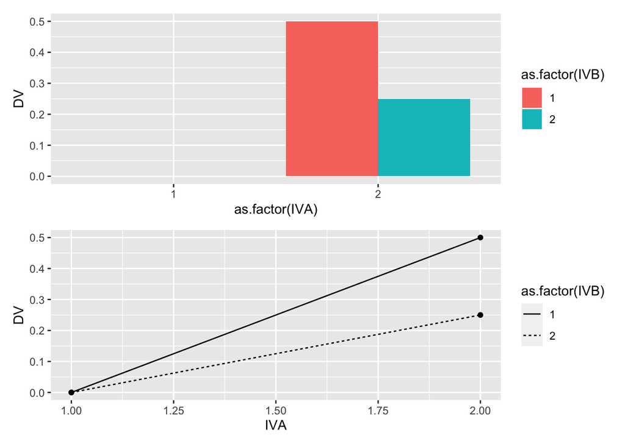

```r
# generate plots
bar_graph <- ggplot(model_data,
                    aes(y=DV,
                        x=as.factor(IVA),
                        fill=as.factor(IVB)))+
  geom_bar(stat='identity', position='dodge')

line_graph <- ggplot(model_data,
                     aes(y=DV,
                         x=IVA,
                         linetype=as.factor(IVB)))+
  geom_line()+
  geom_point()

(bar_graph/line_graph)
```

```r
# N per group
N <- 3

A_pvalue <- c()
B_pvalue <- c()
AB_pvalue <- c()
for(i in 1:10){
  IVA <- rep(rep(c("1","2"), each=2),N)
  IVB <- rep(rep(c("1","2"), 2),N)
  DV <- c(replicate(N,c(rnorm(1,0,1), # means A1B1
                        rnorm(1,0,1), # means A1B2
                        rnorm(1,0.5,1), # means A2B1
                        rnorm(1,0.25,1)  # means A2B2
          )))
  sim_df <- data.frame(IVA,IVB,DV)

  aov_results <- summary(aov(DV~IVA*IVB, sim_df))
  A_pvalue[i]<-aov_results[[1]]$`Pr(>F)`[1]
  B_pvalue[i]<-aov_results[[1]]$`Pr(>F)`[2]
  AB_pvalue[i]<-aov_results[[1]]$`Pr(>F)`[3]
}

length(A_pvalue[A_pvalue<0.05])/1000
```

```
## [1] 0
```

```r
length(B_pvalue[B_pvalue<0.05])/1000
```

```
## [1] 0
```

```r
length(AB_pvalue[AB_pvalue<0.05])/1000
```

```
## [1] 0
```

#### I did this part with before the solution video was posted, and I am not sure if it is correct, but I hope that is what you meant!

```r
library(dplyr)
```

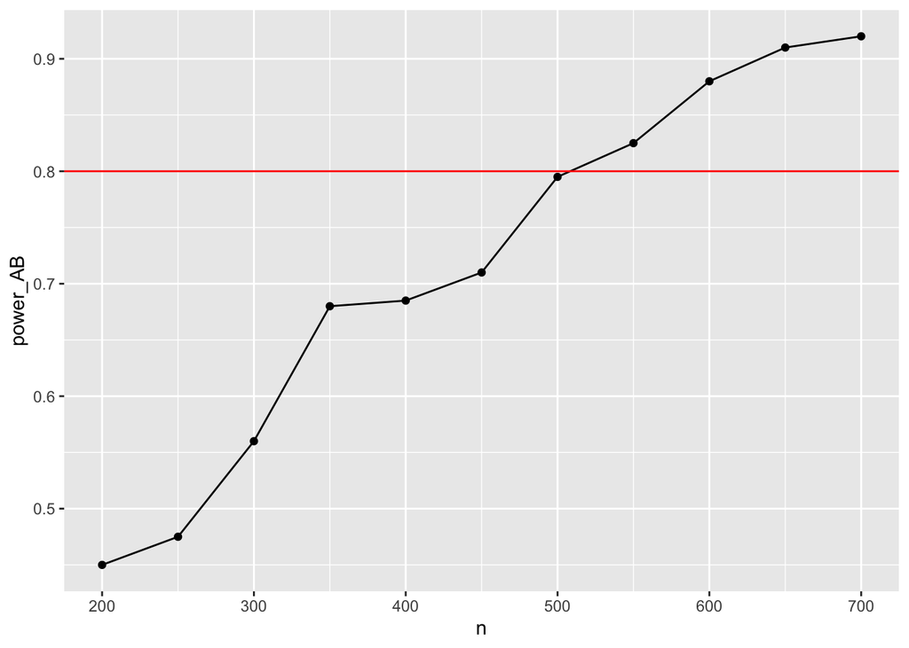

```r
# N per group
n <- seq(200,700,50)
power_AB <- c()

for(j in 1:length(n)){

A_pvalue <- c()
B_pvalue <- c()
AB_pvalue <- c()


for(i in 1:200){
  IVA <- rep(rep(c("1","2"), each=2), n[j])
  IVB <- rep(rep(c("1","2"), 2), n[j])
  DV <- c(replicate(n[j],c(rnorm(1,0,1), # means A1B1
                        rnorm(1,0,1), # means A1B2
                        rnorm(1,0.5,1), # means A2B1
                        rnorm(1,0.25,1)  # means A2B2
          )))
  sim_df <- data.frame(IVA,IVB,DV)

  aov_results <- summary(aov(DV~IVA*IVB, sim_df))
  AB_pvalue[i]<-aov_results[[1]]$`Pr(>F)`[3]
}

power_AB[j] <- length(AB_pvalue[AB_pvalue<0.05])/200
}


plot_data <- data.frame(n, power_AB)

ggplot(plot_data,aes(x=n,y=power_AB))+
  geom_point()+
  geom_line()+
  geom_hline(yintercept=0.8, color="red")
```